# Crypto Analysis

Wilmer Cifuentes

2025-09-01

```r
suppressPackageStartupMessages({
  library(dplyr)
  library(ggplot2)
  library(broom)
})
```

# Introduction

In this report, I analyze my dataset to answer questions using visualization and statistical methods. The dataset is loaded from a CSV file to ensure reproducibility.

```r
crypto <- read.csv("/Users/wilmercifuentes/Downloads/top_100_cryptos_with_correct_network.csv") %>%
  mutate(
    date = as.Date(date),
    network = as.factor(network),
    symbol  = as.factor(symbol)
  )
```

# Q1) Load CSV, plot selected columns and briefly explain.

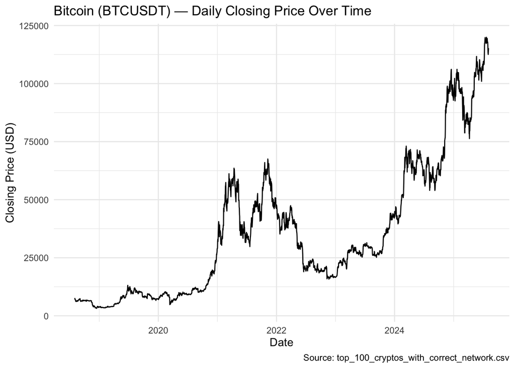

```r
 btc <- filter(crypto, symbol == "BTCUSDT")

ggplot(btc, aes(x = date, y = close)) +
  geom_line() +
  labs(
    title = "Bitcoin (BTCUSDT) — Daily Closing Price Over Time",
    x = "Date",
    y = "Closing Price (USD)",
    caption = "Source: top_100_cryptos_with_correct_network.csv"
  ) +
  theme_minimal()
```

**Explanation:** This line chart shows BTC’s closing price trend, highlighting rallies and drawdowns typical of crypto market volatility

# Q2) Do a simple statistical calculation (e.g., mean, sd) and explain

Here I compute the mean and standard deviation of BTC closing prices.

```r
mean_close_btc <- mean(btc$close, na.rm = TRUE)
sd_close_btc   <- sd(btc$close,   na.rm = TRUE)

data.frame(
  metric = c("Mean closing price (USD)", "Standard deviation (USD)"),
  value  = c(round(mean_close_btc, 2), round(sd_close_btc, 2))
)
```

```
##                     metric    value
## 1 Mean closing price (USD) 35688.33
## 2 Standard deviation (USD) 28971.93
```

**Explanation:**The mean summarizes the typical BTC price level, while the standard deviation measures price variability; a large SD relative to the mean indicates high volatility.

# Q3) Apply correlation or regression to detect a relationship and explain

I examine the relationship between opening and closing prices for BTC via correlation and simple linear regression. # Correlation

```r
corr_btc <- cor(btc$open, btc$close, use = "complete.obs")
```

# Regression: close ~ open

```r
fit_btc   <- lm(close ~ open, data = btc)
coef_tbl  <- tidy(fit_btc)
fit_stats <- glance(fit_btc)

list(
  correlation_open_close = round(corr_btc, 4),
  regression_coefficients = coef_tbl,
  model_fit = fit_stats
)
```

```
## $correlation_open_close
## [1] 0.999
##
## $regression_coefficients
## # A tibble: 2 × 5
##   term        estimate std.error statistic p.value
##   <chr>          <dbl>     <dbl>     <dbl>   <dbl>
## 1 (Intercept)    31.3  40.3          0.776   0.438
## 2 open            1.00  0.000878  1140.      0
##
## $model_fit
## # A tibble: 1 × 12
##   r.squared adj.r.squared sigma statistic p.value    df  logLik    AIC    BIC
##       <dbl>         <dbl> <dbl>     <dbl>   <dbl> <dbl>   <dbl>  <dbl>  <dbl>
## 1     0.998         0.998 1285.  1299188.       0     1 -21975. 43955. 43973.
## # ℹ 3 more variables: deviance <dbl>, df.residual <int>, nobs <int>
```

**Explanation:** The correlation quantifies linear association strength. The regression slope indicates how much close changes per unit change in open. A small slope p-value (e.g., < 0.05) indicates a statistically significant relationship.